# DBDC - Visualización de Datos - Tarea 1

2023

Autor/a

Joshua Kunst

## Consideraciones

- La fecha de entrega es domingo 13 agosto 2023 a las 23:59.
- La evaluación se puede realizar de a lo más 2 alumnos.
- Para facilitar y agilizar la correción se agradece considerar que el archivo a enviar sea: `eval1_nombre1_nombre2.R` o `eval1_nombre1_nombre2.ipynb`. Ejemplo `eval1_Tulio_Treviño_Carlos_Bodoque.R`.
- Enviar un archivo por grupo a la dirección `jbkunst@gmail.com` con el asunto **DBDC-Viz-1: Nombre1 y Nombre2**. Ejemplo *DBDC-Viz-1: Tulio Treviño y Carlos Bodoque*.
- El archivo debe ser reproducible, en el sentido de quien evalue pueda correr línea a línea, i.e. en orden, sin error los códigos del script.
- La evaluación no se basa solamente en los *outputs* como tablas o gráficos sino también en los argumentos y comentarios realizados.

En esta tarea utilizaremos los siguientes paquetes. Asegúrese de tenerlos instalados previamente.

```r
library(tidyverse)
library(datos)
```

## Items

### Datos 1

Para las siguientes preguntas considere el siguiente data frame:

```r
df <- tibble(
  x = c(2, 1, 3, 5, 6, 4),
  y = c(2, 4, 6, 7, 4, 1),
  v = c(1, 1, 1, 2, 2, 2)
)

df
```

```
# A tibble: 6 × 3
      x     y     v
  <dbl> <dbl> <dbl>
1     2     2     1
2     1     4     1
3     3     6     1
4     5     7     2
5     6     4     2
6     4     1     2
```

### Item 1 (1 pto.)

Grafique los datos utilizando `geom_line()`, `geom_path()` y `geom_polygon()` graficando las variables `x` e `y`, comente:

- Describa que hace `geom_path()` a diferencia de `geom_line()`.
- Mencione que hace `geom_polygon()` a diferencia de `geom_path()`.

### Item 2 (1 pto.)

Considere el código de los 3 gráficos del item anterior pero ahora agregue a cada uno de ellos a la estética el agrumento `group` usando la variable `v`. Es decir `aes(x, y, group = v)`.

- Menciona los cambios obtenidos respecto a los resultados anteriormente obtenidos.
- ¿Cuál sería un tipo de datos donde `geom_path()` sea la función a utilizar sobre `geom_line()`?

### Datos 2

Para el siguiente ejercicio consideraremos las siguientes tablas:

- **`estados`** correspondiente a la información geográfica de los Estados Unidos.
- **`topdestinos`** el cual contiene información del *Top 20* de los destinos de la tabla `vuelos` del paquete `datos`.

```r
estados <- as_tibble(map_data("state"))
estados
```

```
# A tibble: 15,537 × 6
    long   lat group order region  subregion
   <dbl> <dbl> <dbl> <int> <chr>   <chr>
 1 -87.5  30.4     1     1 alabama <NA>
 2 -87.5  30.4     1     2 alabama <NA>
 3 -87.5  30.4     1     3 alabama <NA>
 4 -87.5  30.3     1     4 alabama <NA>
 5 -87.6  30.3     1     5 alabama <NA>
 6 -87.6  30.3     1     6 alabama <NA>
 7 -87.6  30.3     1     7 alabama <NA>
 8 -87.6  30.3     1     8 alabama <NA>
 9 -87.7  30.3     1     9 alabama <NA>
10 -87.8  30.3     1    10 alabama <NA>
# ℹ 15,527 more rows
```

```r
topdestinos <- vuelos |>
  count(codigo_aeropuerto = destino, sort = TRUE) |>
  left_join(
    aeropuertos |>
      select(codigo_aeropuerto, latitud, longitud),
    by = join_by(codigo_aeropuerto)
    ) |>
  head(20)

topdestinos
```

```
# A tibble: 20 × 4
   codigo_aeropuerto     n latitud longitud
   <chr>             <int>   <dbl>    <dbl>
 1 ORD               17283    42.0    -87.9
 2 ATL               17215    33.6    -84.4
 3 LAX               16174    33.9   -118.
 4 BOS               15508    42.4    -71.0
 5 MCO               14082    28.4    -81.3
 6 CLT               14064    35.2    -80.9
 7 SFO               13331    37.6   -122.
 8 FLL               12055    26.1    -80.2
 9 MIA               11728    25.8    -80.3
10 DCA                9705    38.9    -77.0
11 DTW                9384    42.2    -83.4
12 DFW                8738    32.9    -97.0
13 RDU                8163    35.9    -78.8
14 TPA                7466    28.0    -82.5
15 DEN                7266    39.9   -105.
16 IAH                7198    30.0    -95.3
17 MSP                7185    44.9    -93.2
18 PBI                6554    26.7    -80.1
19 BNA                6333    36.1    -86.7
20 LAS                5997    36.1   -115.
```

### Item 3 (1 pto.)

Con los datos `estados` y la función `geom_polygon()` gener un mapa de estados unidos. En la función `geom_polygon()` utilice el argumento `col = "gray70"` y `fill = "gray90"` para que la capa sea *suave*.

### Item 4 (2 ptos.)

Al gráfico anterior:

1. Utilizando los datos `topdestinos`, agregue una capa de puntos codificando la información de la posición de la estación y la cantidad de vuelos hacia dicho aeropuerto.
2. Argumente su elección del tipo de **canal** que ha utilizado para representar la cantidad de vuelos.
3. Revise la documentation de `coord_map()` y por que es relevante su uso en el contexto del ejercicio.
4. Aplique `coord_map()` y comente lo obtenido con el gráfico del ítem anterior.

### Item 5 (2 ptos.)

En el post con nombre [Land doesn’t vote, people do](https://www.core77.com/posts/90771/A-Great-Example-of-Better-Data-Visualization-This-Voting-Map-GIF) se muestran los siguientes dos gráficos:

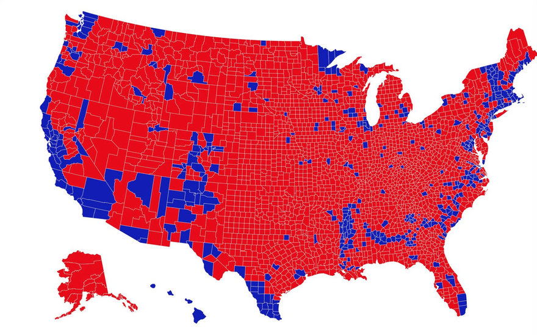

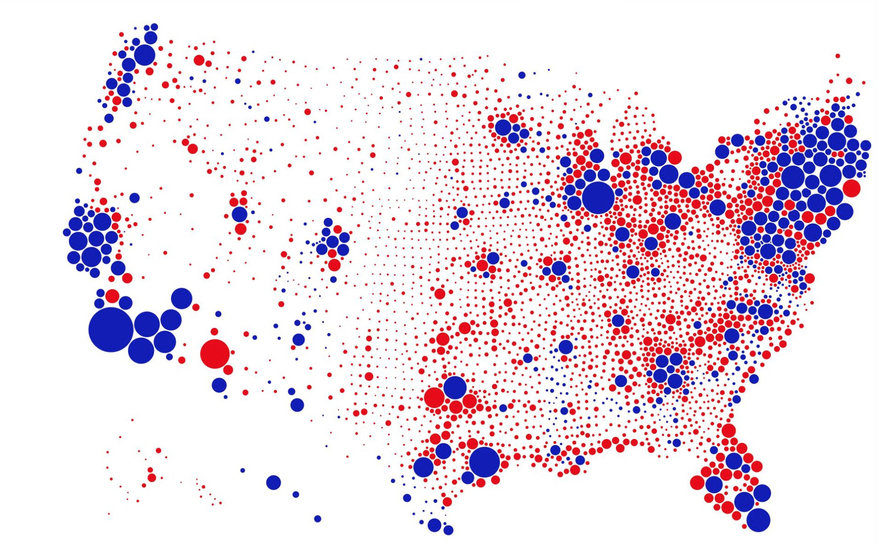

Realice un análisis sobre la posibilidad de inducir error en el caso expuesto; comparando e indicando los tipos de atributos (variables) usados en los gráficos y aspectos técnicos sobre las **marcas** y **canales** empleados en cada gráfico, es decir explicar claramente **que** información se codifica y **como** esta es codificada. Mencione además, de que forma podría mejorar el gráfico de la izquierda utilizando otros canales.

### Datos 3

El siguiente set de datos que describe 12 periodos presidenciales de EE.UU.

```r
presidencial
```

```
# A tibble: 12 × 4
   nombre     inicio     fin        partido
   <chr>      <date>     <date>     <chr>
 1 Eisenhower 1953-01-20 1961-01-20 Republicano
 2 Kennedy    1961-01-20 1963-11-22 Demócrata
 3 Johnson    1963-11-22 1969-01-20 Demócrata
 4 Nixon      1969-01-20 1974-08-09 Republicano
 5 Ford       1974-08-09 1977-01-20 Republicano
 6 Carter     1977-01-20 1981-01-20 Demócrata
 7 Reagan     1981-01-20 1989-01-20 Republicano
 8 Bush       1989-01-20 1993-01-20 Republicano
 9 Clinton    1993-01-20 2001-01-20 Demócrata
10 Bush       2001-01-20 2009-01-20 Republicano
11 Obama      2009-01-20 2017-01-20 Demócrata
12 Trump      2017-01-20 2021-01-20 Republicano
```

### Item 6 (2 ptos.)

Considere la tabla `presidencial` para visualizar como se ha distribuído el tiempo entre partidos o en su defecto indiar periodos históricos importantes. Puede generar más de una visualización, generar/**derivar** variables adicionales, utilizar colores acordes al contexto de los datos, etc.

Al generar la(s) visualización(es) explique:

- El **WHAT**, **HOW**, **WHY**.
- Que es lo que está codificando en términos de **marcas** y **canales**.

Este item no es obligación utilizar `ggplot2`.